# TWoLife: Simulating Populations with Individual Variation in Heterogeneous Landscapes

Lucas Freitas

2026-02-25

# 1 Introduction

The **TWoLife** package implements individual-based simulations of populations inhabiting spatially heterogeneous landscapes. Unlike traditional models that assume genetic uniformity within populations, TWoLife explicitly represents individual variation in traits that determine ecological outcomes. As a consequence, the package allows researchers to investigate how preexisting genetic diversity interacts with landscape structure to influence population persistence (Bolnick et al. 2003; Barrett and Schluter 2008).

The package addresses a fundamental limitation of ecological theory: the assumption that individuals within a population perceive and exploit environments in identical ways. This assumption, while simplifying mathematical analysis, may not depict biologically realistic scenarios (Bolnick et al. 2011). In reality, individuals differ in their optimal environmental conditions, tolerance ranges, and behavioral strategies. This in turn means that environmental changes may favor some individuals to the detriment of others, with consequences for population-level outcomes that cannot be predicted from species-level averages alone (Violle et al. 2012).

TWoLife enables researchers to:

1. Generate landscapes with **continuous environmental gradients** representing variation in conditions across space, or **discrete habitat patches** embedded in unsuitable matrix
2. Model **individual genetic variation** in optimal environmental values, tolerance ranges (niche width), and behavioral strategies
3. Implement **evolutionary and adaptive mechanisms** including mutation (heritable genetic changes), phenotypic plasticity (non-heritable developmental noise), and natural selection
4. Track **phenotype-environment interactions** where fitness emerges dynamically from the match between individual traits and local conditions, rather than being pre-assigned by habitat type
5. Analyze **emergent population dynamics** arising from individual-level processes of birth, death, dispersal, and trait evolution

This vignette first introduces the package’s key concepts, function structure, and output format, then demonstrates TWoLife’s core capability through a worked analysis: modeling populations where fitness emerges dynamically from phenotype–environment matching along continuous gradients. Through a progressive five-scenario comparison, we isolate the contributions of genetic diversity, tolerance, evolutionary processes, and habitat selection behavior to population persistence. This design directly addresses a question that habitat-quality models cannot: which individual-level mechanisms are necessary for populations to persist across heterogeneous environments?

# 2 Key Concepts

## 2.1 Landscapes

Spatial environments in TWoLife are represented as rectangular numeric matrices where each cell contains an environmental value. The package supports two fundamentally different landscape types that determine how environmental variation structures individual fitness:

- **Continuous landscapes**: Environmental values vary along gradients, typically rescaled to a user-defined range (e.g., 0.0 to 100.0 as used throughout this vignette). These values represent continuous variation in conditions such as temperature, soil moisture, or resource availability. In continuous landscapes, no locations are inherently unsuitable. Rather, suitability emerges dynamically from the interaction between individual phenotypes and local environmental values through Gaussian matching (explained in the Fitness section below). This means that a cell with value 3 is not intrinsically “better” or “worse” than a cell with value 10 — suitability depends on whether individuals in the population possess phenotypes adapted to those particular values.
- **Discrete landscapes**: Space is divided into binary categories where cells are classified as either suitable habitat (value=1) or unsuitable matrix (value=0). Individuals can persist only in habitat cells; matrix cells are immediately lethal regardless of individual traits. This paradigm corresponds to traditional patch-matrix landscape ecology (Fahrig 2003).

Landscapes are generated using `create_fractal_landscape()`, which produces realistic spatial patterns with self-similar structure across scales (Justeau-Allaire et al. 2022). The fractal algorithm ensures that pattern complexity — the degree of patchiness versus smoothness — remains similar whether the landscape is viewed at fine resolution (individual cells) or coarse resolution (blocks of cells). This property mimics natural spatial processes where environmental structure often exhibits scale-invariant patterns (Milne 1992; Wiens 1976).

## 2.2 Individuals

Individuals are characterized by five genetic attributes that together determine ecological and evolutionary outcomes:

- **`genotype_mean`** (Optimal environmental value): The environmental condition at which the individual achieves maximum fitness, representing the genetically-determined optimal niche position. Values ideally match in the landscape’s environmental scale. For example, an individual with genotype_mean=0.3 is genetically adapted to environmental value 0.3 (e.g., cool temperatures if the gradient represents temperature). When an individual’s phenotype (genotype_mean plus noise from plasticity) exactly matches the local environmental value, fitness equals to its maximum.
- **`genotype_sd`** (Niche width/tolerance): The breadth of environmental conditions the individual can tolerate, represented mathematically as the standard deviation ($\sigma$) in the Gaussian fitness function. This parameter governs the specialist-generalist tradeoff: values near $\sigma_{min}$ (e.g., genotype_sd=0.4) yield near-maximum peak fitness with a very steep fitness decline away from the optimum — on a 0–100 landscape this niche width covers only $\approx 0.4$% of the environmental range, representing a true narrow specialist. Larger values (e.g., genotype_sd=5.0) produce broader tolerance but lower peak fitness, illustrating the “jack of all trades, master of none” pattern (Levins 1968; Futuyma and Moreno 1988).
- **`mutation_rate`** (Mutation rate): Controls heritable genetic variation transmitted across generations. This parameter determines the standard deviation (μ_r) of mutations added to the offspring’s genotype at each birth event. Unlike plasticity, which affects phenotype but not inheritance, mutations modify the genotype itself and these modifications are passed to future generations. This enables evolutionary adaptation—populations can shift their genetic composition in response to selection pressures (Lynch and Walsh 1998). The underlying mathematical model is:

  $g_{\text{offspring}} = g_{\text{parent}} + \varepsilon_{\text{mutation}}$

  where $\varepsilon_{\text{mutation}} \sim N(0, \mu_r)$ and $\mu_r$ = mutation_rate parameter.
- **`plasticity`** (Phenotypic plasticity): Controls non-heritable phenotypic variation arising from developmental or environmental noise. This parameter determines the standard deviation (ψ) of random variation added to an individual’s genotype at birth to produce its phenotype, which then remains fixed for the individual’s lifetime. Importantly, the phenotype (not genotype) determines fitness and habitat selection, while only the genotype is transmitted to offspring. This distinction allows modeling of developmental variation that affects individual ecology but is not inherited (Pigliucci 2001; DeWitt and Scheiner 2004). Mathematically, the relationship can be expressed as:

  $p = g + \varepsilon_{\text{plasticity}}$

  where $\varepsilon_{\text{plasticity}} \sim N(0, \psi)$ and $\psi$ = plasticity parameter (same principle as mutation).
- **`sampling_points`** (Habitat selection intensity): The number of potential dispersal locations an individual evaluates before deciding where to move. When sampling_points is set to 0 or 1, individuals move to randomly chosen locations without evaluation, representing passive dispersal mechanisms. These two values are conceptually equivalent in producing passive dispersal but differ in implementation—0 triggers a random walk algorithm while 1 samples a single random location. As sampling_points increases, individuals gain the capacity to assess and compare multiple locations before settling, selecting among them using a softmax function weighted by expected fitness. Unlike the ideal free distribution (Fretwell and Lucas 1970), which assumes perfect information, the softmax implements probabilistic choice under limited sampling — a bounded-rationality decision rule in which the temperature parameter controls the sharpness of preference (McNamara and Houston 1987). Higher values enable increasingly sophisticated habitat selection and increase computation time linearly, but the softmax process retains some randomness to prevent unrealistic determinism where all individuals always select the single best available cell.

All five attributes are heritable, enabling evolutionary dynamics and potential local adaptation over multiple generations (Kawecki and Ebert 2004). Fitness emerges from the interaction between these traits and local conditions, as defined in the Fitness section below.

## 2.3 Fitness: How Traits Determine Survival

Survival-related processes in TWoLife are determined by Gaussian matching—a mathematical function that quantifies how well an individual’s phenotype matches local environmental conditions. This fitness framework differs fundamentally from models where habitat quality is pre-assigned by location type (e.g., habitat cells support survival, matrix cells do not). Instead, fitness emerges dynamically from trait-environment interactions:

$$W = \frac{1}{\sigma\sqrt{2\pi}}
\exp\left(-\frac{(h - p)^2}{2\sigma^2}\right)$$

where:

- $W$ is the individual’s fitness (a probability density value)
- $p$ (phenotype) is the individual’s expressed trait value (genotype_mean plus developmental noise from the plasticity parameter, sampled once at birth; see Individuals section above)
- $h$ (environment) is the environmental value at the cell where the individual currently resides (ranging from 0 to 100 in the continuous landscape used throughout this vignette, though any numeric range is valid; or 0/1 in binary landscapes)
- $\sigma$ (genotype_sd) is the individual’s tolerance parameter (niche width; see Individuals section above)

This function uses the **probability density form** of the Gaussian, which introduces a critical tradeoff. At a perfect phenotype-environment match ($h = p$), fitness equals $1/(\sigma\sqrt{2\pi})$. Peak fitness therefore *declines* as $\sigma$ increases. The constraint

$\sigma \geq \sigma_{min} = 1/\sqrt{2\pi} \approx 0.3989$

prevents fitness from exceeding 1.0: at $\sigma = \sigma_{min}$, peak fitness equals exactly 1.0; for all larger $\sigma$, peak fitness falls below 1.0.

This creates an explicit **specialist-generalist tradeoff**: narrow niche width (small $\sigma$, near $\sigma_{min}$) yields near-maximum peak fitness but steep fitness decline away from the optimum, while broad niche width (large $\sigma$) yields moderate fitness across a wide range of conditions but never achieves peak performance — the “jack of all trades, master of none” pattern (Levins 1968). Note that $\sigma = 0$ is a separate special case handled by discrete logic (perfect specialists; see below), so valid values for Gaussian fitness individuals are either exactly 0 or at least $\approx 0.3989$.

Rather than acting directly as a survival probability, fitness $W$ in TWoLife modulates mortality rate. Mortality is bounded between a minimum rate in optimal habitat ($\mu_{min}$ = base_mortality_rate) and a maximum rate in highly unsuitable habitat ($\mu_{max}$ = base_mortality_rate $\times$ matrix_mortality_multiplier). Fitness determines where within this range an individual’s mortality falls:

$$\mu = \mu_{max} - W\left(\mu_{max} - \mu_{min}\right)$$

Under this formulation, individuals with fitness near 1.0 experience near-minimum mortality, while individuals with very low fitness approach maximum mortality. Because the PDF fitness formulation means peak $W < 1$ for most $\sigma$ values, even well-matched individuals experience mortality slightly above $\mu_{min}$; only individuals with $\sigma = \sigma_{min}$ achieve $\mu_{min}$ in perfect habitat. This smoothly implements stabilizing selection through environment-dependent survival (Lande 1976) while keeping mortality rates biologically interpretable and bounded.

The figure below makes this tradeoff concrete using the parameter values from the Main Analysis: `base_mortality_rate = 0.2` ($\mu_{min}$) and `matrix_mortality_multiplier = 2.0`, which together give $\mu_{max} = 0.2 \times 2.0 = 0.4$. The display window spans $h \in [0, 10]$ with the individual’s phenotype at $p = 5.0$ (midpoint). Four $\sigma$ values are shown: the critical threshold $\sigma_{min}$; $\sigma = 0.5$; $\sigma = 0.8$; and $\sigma = 1.0$. All four values are deliberately close together to highlight how even small increases in niche width carry a measurable mortality cost at the optimum. Filled circles mark each curve’s lowest point ($h = p = 5.0$); colored tick marks on the right axis give the exact $\mu_{opt}$ for each curve:

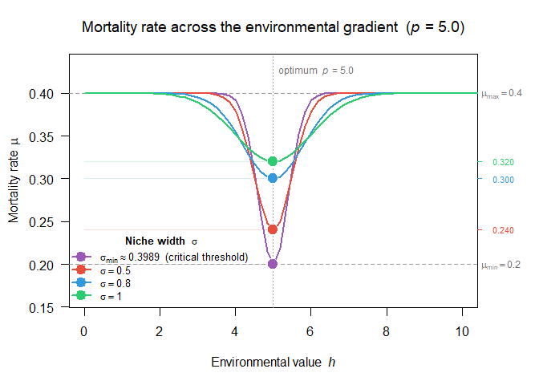

# 3 Package Overview

We begin by loading the package:

```r
library(TWoLife)
```

## 3.1 Main Function

TWoLife simulations are executed through a single main function that accepts five components organized to separate spatial, demographic, genetic, temporal, and stochastic aspects of the model. Demographic events are scheduled using the Gillespie algorithm, which generates exact stochastic trajectories from continuous-time event rates (Gillespie 1976, 1977). This organization reflects the structure of individual-based models more generally, where populations are defined by their environment (landscape), initial configuration (individuals), heritable variation (genetics), and temporal dynamics (simulation parameters), with stochasticity controlled through seeding (Grimm and Railsback 2005; DeAngelis and Mooij 2005).

The four parameter lists are:

- **landscape_params**: A list containing spatial environment configuration, specifically the habitat matrix and optionally environmental values
- **individual_params**: A list containing population initialization settings (starting population size and positions)
- **genetic_params**: An optional list specifying individual variation in genetic traits (optimal values, tolerance, mutation rates, plasticity, and behavior)
- **simulation_params**: A list containing simulation control and stopping conditions (duration limits)

The fifth component is **master_seed**, an integer value that ensures complete reproducibility by controlling all random processes in the simulation, from initial individual placement to demographic event ordering to mutation directions.

The function structure is:

```r
twolife_simulation(
  landscape_params,
  individual_params,
  genetic_params,
  simulation_params,
  master_seed
)
```

**Important note on genetic_params**: This list is optional. When `genetic_params` is omitted, TWoLife applies default values designed specifically for binary landscapes where habitat=1 and matrix=0. Under these defaults, all individuals have genotype_mean=1 (matching habitat value), genotype_sd=0 (zero tolerance, requiring exact environmental matches), mutation_rate=0 (no evolution), plasticity=0 (no phenotypic noise), and sampling_points=0 (random dispersal). These defaults work well for exploring habitat-matrix simulations without genetic complications, as they create genetically uniform populations that survive in habitat cells but not matrix cells. However, these same defaults typically produce extinction in continuous landscapes where exact environmental matches are rare. As a consequence, explicit genetic_params specification is essential when working with continuous environmental gradients (demonstrated in the Main Analysis below).

The `simulation_params` list controls simulation duration through `max_events` (maximum number of demographic events). The `master_seed` ensures reproducibility: identical parameters and seed produce identical results, while different seeds produce independent stochastic iterations. Note that exact reproducibility also requires the same TWoLife and R versions.

## 3.2 Simulation Output

Simulations return a list object containing four components that provide different levels of detail about population outcomes. This structure balances the need for quick summaries (summary component), detailed individual-level data (survivors component), complete demographic records (events component), and reproducibility (parameters component):

- **`summary`**: A list of final population statistics including `final_population_size` (number surviving at simulation end), `total_births` (cumulative birth events), `total_deaths` (cumulative death events), `total_dispersals` (cumulative dispersal events), and `final_time` (simulation duration). This component provides quick assessment of population outcomes without requiring data processing.
- **`survivors`**: A data frame where each row represents one surviving individual at simulation end. Columns include `individual_id`, `genotype` (genotype_mean value), `genotype_sd` (niche width), `phenotype` (expressed environmental optimum), `x` and `y` (spatial coordinates). This component enables analysis of trait distributions, spatial patterns, and phenotype-environment matching among survivors. When populations go extinct, this component may be NULL or an empty dataframe.
- **`events`**: A data frame recording every demographic event that occurred during the simulation. The level of detail depends on the `history_detail` parameter (set in `simulation_params`). At minimum (`history_detail="minimal"`), each row documents one event with columns: `time` (when event occurred), `event_type` (0=death, 1=birth, 2=dispersal, 3=emigration, -1=initial state), and `individual_id`. Standard detail (`history_detail="standard"`, the default) additionally includes `patch_id`, `x` and `y` coordinates, and `genotype`. Full detail (`history_detail="full"`) further adds `phenotype` and `width` (genotype_sd). This complete history enables analysis of population dynamics, demographic rates over time, and lineage tracking.
- **`parameters`**: A list storing all input parameters (landscape_params, individual_params, genetic_params, simulation_params, master_seed). This ensures complete reproducibility—simulations can be exactly replicated by re-running with stored parameters. It also enables systematic comparison across simulations with different parameter configurations.

# 4 Main Analysis: Individual Variation in Heterogeneous Environments

TWoLife’s distinguishing capability is modeling populations where individual fitness emerges from phenotype–environment matching along continuous environmental gradients, rather than being pre-assigned by habitat type. This section demonstrates that capability through a controlled comparison of five scenarios that differ only in which individual-level mechanisms are active, holding all other conditions constant (landscape structure, initial population size, simulation duration, and random seeds).

The scenarios progressively add mechanisms: genetic diversity in optimal trait values, tolerance (niche width), evolutionary processes (mutation and plasticity), and habitat selection behavior. This progression allows each mechanism’s contribution to be read off directly from the change in population outcome between adjacent scenarios, and tests whether mechanisms interact additively or synergistically.

## 4.1 Landscape and Experimental Design

We generate the continuous landscape shared by all five scenarios:

```r
set.seed(50)
continuous_landscape <- create_fractal_landscape(
  cells_per_row = 5,             # 5×5 = 25 total cells
  fractality = 0.5,              # Balanced spatial autocorrelation
  min_value = 0.0,               # Minimum environmental value
  max_value = 100.0              # Maximum environmental value
)
```

The resulting 25-cell (5×5) landscape spans values from 0.0 to 100.0 with intermediate-scale spatial structure (fractality=0.5). No cell is inherently suitable or unsuitable—suitability depends entirely on phenotype–environment matching, as established in Key Concepts.

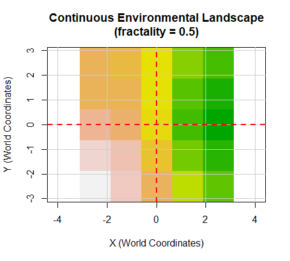

We implement five scenarios that differ only in genetic parameters, with all other conditions held constant. This factorial design allows us to isolate each mechanism’s contribution to population outcomes. The order of mechanism addition follows a biological hierarchy from fundamental to facultative: (1) genetic diversity in optimal values is the most basic requirement—populations need variation to span environmental gradients; (2) tolerance (niche width) enables each genotype to survive across a range of conditions rather than requiring exact matches; (3) evolution (mutation + plasticity) allows populations to generate new variation and fine-tune existing variation through natural selection; (4) behavior (habitat selection) enables individuals to actively locate suitable habitats rather than dispersing randomly:

| Scenario | Genetic Diversity | Niche Width | Evolution | Behavior | Configuration |
| --- | --- | --- | --- | --- | --- |
| 1. Uniform specialists | No (all genotype=1.0) | No (sds=0) | No | No | Default parameters |
| 2. Variable specialists | Yes (genotypes 0–100) | No (sds=0) | No | No | genotype_means only |
| 3. Generalists | Yes | **Yes (sds=0.4)** | No | No | Add genotype_sds |
| 4. Evolution | Yes | Yes | **Yes** (mutation + plasticity) | No | Add mutation, plasticity |
| 5. Habitat selection | Yes | Yes | Yes | **Yes** (sampling=10) | Add sampling_points, temperature |

All scenarios use identical conditions except genetic parameters: same landscape (continuous_landscape generated above), same initial population size (N=1000, supersaturated relative to landscape carrying capacity), and same simulation duration (100 demographic events, chosen to be computationally lightweight while still revealing which mechanisms enable persistence).

Before running the scenarios we define all shared parameters exactly once:

```r
# ── Population size and initial genotypes ────────────────────────────────────
# Uniformly-spaced genotypes span the full environmental gradient (0–100)
# so that each of the 1 000 individuals begins with a distinct optimum.
# Using a deterministic sequence (rather than random draws) ensures that
# genetic composition is identical across scenarios 2–5.
initial_pop_size  <- 1000
initial_genotypes <- seq(0, 100, length.out = initial_pop_size)

# ── Shared landscape parameters ──────────────────────────────────────────────
# All five scenarios run on the same landscape with the same configuration.
shared_landscape_params <- list(
  habitat                     = continuous_landscape,
  cell_size                   = 1.0,
  boundary_condition          = 1,     # reflective: individuals bounce off borders
  density_type                = 1,     # local density within neighbor_radius
  matrix_mortality_multiplier = 2.0,   # μ_max = 2 × μ_min = 0.4
  matrix_dispersal_multiplier = 0.5
)

# ── Shared individual parameters ─────────────────────────────────────────────
# Demographic rates and movement geometry are identical across scenarios.
shared_individual_params <- list(
  initial_population_size = initial_pop_size,
  neighbor_radius         = 2.0,
  vision_angle            = pi,
  step_length             = 5.0,
  base_dispersal_rate     = 0.4,
  base_birth_rate         = 0.6,
  base_mortality_rate     = 0.2,
  birth_density_slope     = 0.02,
  mortality_density_slope = 0.02
)

# ── Shared simulation parameters ─────────────────────────────────────────────
# 100 demographic events per scenario — the smaller 5×5 landscape keeps
# runtimes short while providing enough time to distinguish the five
# ecological strategies.
shared_simulation_params <- list(max_events = 100)
```

## 4.2 Scenario 1: Uniform Perfect Specialists

This scenario demonstrates default behavior when `genetic_params` is omitted: all individuals are genetically identical with genotype_mean=1.0 and genotype_sd=0.

```r
# Only genetic_params is omitted — every other argument comes from the
# shared lists defined above.  This makes the scenario's distinctive
# choice (no genetic variation) immediately visible.
sim_s1 <- twolife_simulation(
  landscape_params  = shared_landscape_params,
  individual_params = shared_individual_params,
  # genetic_params omitted → defaults: all genotype_mean = 1.0, genotype_sd = 0
  simulation_params = shared_simulation_params,
  master_seed = 45
)

(pop_s1 <- sim_s1$summary$final_population_size)
```

```
#> [1] 0
```

The simulation results in N = 0 (extinction). Zero tolerance (`genotype_sd = 0`) means individuals require exact environmental matches that probably do not exist in the continuous landscape (range: 0.00 to 100.00). Starting with genotype_mean = 1.0, only cells with exactly that environmental value produce minimum mortality—any other value produces maximum mortality—demonstrating that genetic uniformity combined with specialist strategies is incompatible with persistence in heterogeneous continuous environments.

## 4.3 Scenario 2: Variable Specialists

This scenario adds genetic diversity: each of the 1000 individuals has a distinct genotype_mean spanning 0 to 100, but genotype_sd remains 0 (perfect specialists still requiring exact environmental matches).

```r
# Adding genotype_means is the only change from Scenario 1.
# genotype_sds still defaults to 0 (perfect specialists).
sim_s2 <- twolife_simulation(
  landscape_params  = shared_landscape_params,
  individual_params = shared_individual_params,
  genetic_params = list(
    genotype_means = initial_genotypes   # 1 000 distinct optima spanning 0–100
    # genotype_sds defaults to 0 → perfect specialists, no tolerance
  ),
  simulation_params = shared_simulation_params,
  master_seed = 46
)

(pop_s2 <- sim_s2$summary$final_population_size)
```

```
#> [1] 0
```

The simulation results in N = 0 (extinction). Despite having 1000 different genotypes spanning the full environmental range (0–100), zero tolerance means individuals still require exact environmental matches. In continuous space, exact matches rarely occur—even if an individual has `genotype_mean = 5.0` and a cell has `environment = 5.0`, any slight mismatch produces effectively zero fitness when `genotype_sd = 0`. This demonstrates that genetic diversity alone is insufficient without tolerance enabling survival across a range of conditions.

## 4.4 Scenario 3: Generalists (Niche Width)

This example demonstrates the effect of adding tolerance (genotype_sd). Each individual has the same genotype_mean as Scenario 2 (maintaining identical genetic diversity), but now with genotype_sd=0.4, enabling survival across a small range of conditions around their optima.

```r
# Only genetic_params changes from S2: genotype_sds is now 0.4.
# landscape, individual, and simulation arguments are inherited unchanged.
sim_s3 <- twolife_simulation(
  landscape_params  = shared_landscape_params,
  individual_params = shared_individual_params,
  genetic_params = list(
    genotype_means = initial_genotypes,
    genotype_sds   = rep(0.4, initial_pop_size)   # key change: add niche width
    # mutation_rates  defaults to 0 → no evolution
    # plasticities    defaults to 0 → no phenotypic noise
    # sampling_points defaults to 0 → random walk dispersal
  ),
  simulation_params = shared_simulation_params,
  master_seed = 47
)

(pop_s3 <- sim_s3$summary$final_population_size)
```

```
#> [1] 148
```

The simulation results in N = 148 (14.8% survival), compared to N=0 in Scenarios 1-2. Adding tolerance enables population persistence by allowing individuals to survive in cells where their phenotype does not exactly match the local environment. With genotype_sd=0.4 (just above $\sigma_{min} \approx 0.3989$), individuals achieve near-maximum peak fitness at their optimum with a very steep fitness decline away from it — niche width covers only $\approx 0.4$% of the 0–100 environmental range, so individuals are genuinely narrow specialists. This tolerance interacts with genetic diversity: because different individuals have different optima spanning 0 to 100, collectively they can utilize the full environmental gradient.

Survivor genotype distribution reveals which individuals persisted:

```r
# Examine survivor trait distribution
if (pop_s3 > 0) {
  survivor_summary <- c(
    Mean_genotype = mean(sim_s3$survivors$genotype),
    SD_genotype = sd(sim_s3$survivors$genotype),
    Range = paste0("[", sprintf("%.2f", min(sim_s3$survivors$genotype)),
                   ", ", sprintf("%.2f", max(sim_s3$survivors$genotype)), "]")
  )
  survivor_summary
}
```

```
#>      Mean_genotype        SD_genotype              Range
#> "44.9605010415821"  "23.211652101043"    "[6.31, 83.28]"
```

## 4.5 Scenario 4: Evolution (Mutation + Plasticity)

This example demonstrates adding evolutionary mechanisms (mutation and plasticity) to the diversity and tolerance from Scenario 3. Mutation (mutation_rate=0.001) enables heritable genetic change across generations, while plasticity (plasticity=0.001) enables non-heritable phenotypic variation within lifetimes.

```r
# Two parameters added to S3's genetic_params: mutation_rates and plasticities.
# All other arguments are unchanged.
sim_s4 <- twolife_simulation(
  landscape_params  = shared_landscape_params,
  individual_params = shared_individual_params,
  genetic_params = list(
    genotype_means = initial_genotypes,
    genotype_sds   = rep(0.4,   initial_pop_size),
    mutation_rates = rep(0.001, initial_pop_size),   # heritable variation across generations
    plasticities   = rep(0.001, initial_pop_size)    # non-heritable phenotypic noise
    # sampling_points defaults to 0 → random walk dispersal still
  ),
  simulation_params = shared_simulation_params,
  master_seed = 48
)

(pop_s4 <- sim_s4$summary$final_population_size)
```

```
#> [1] 201
```

```r
(delta_evolution <- pop_s4 - pop_s3)
```

```
#> [1] 53
```

The simulation results in N = 201 (change: 53 from Scenario 3). This scenario instantiates eco-evolutionary dynamics: mutation and plasticity operate on the same timescale as demographic events, so evolutionary change and population persistence are inseparable processes (Hairston et al. 2005; Schoener 2011). Whether this rapid evolution prevents extinction — an instance of evolutionary rescue — depends on whether genetic variation can be generated and selected fast enough to track the heterogeneous environment (Bell and Gonzalez 2009). Mutation allows the population to explore genetic space beyond the initial genotype distribution (0–100), potentially adapting to local environmental conditions if selection favors particular genotypes. Plasticity allows phenotypes to deviate from genotypes, which can be beneficial if it increases variance in trait-environment matching, though it can also be detrimental if it moves phenotypes away from local optima. The net effect depends on the balance between these processes over the simulation duration.

## 4.6 Scenario 5: Habitat Selection (Behavioral Optimization)

This example demonstrates adding habitat selection behavior (sampling_points=10) to all mechanisms from Scenario 4. Individuals evaluate 10 potential dispersal locations and preferentially select high-fitness sites through softmax weighting with temperature=0.1. Lower temperature values sharpen the softmax preference toward the best available location; at 0.1, selection is fairly strong while retaining some stochasticity.

```r
# Two parameters added to S4's genetic_params: sampling_points and temperatures.
# The pattern is now clear: each scenario extends the previous genetic_params
# by adding one new mechanism, while shared parameters remain untouched.
sim_s5 <- twolife_simulation(
  landscape_params  = shared_landscape_params,
  individual_params = shared_individual_params,
  genetic_params = list(
    genotype_means                 = initial_genotypes,
    genotype_sds                   = rep(0.4,   initial_pop_size),
    mutation_rates                 = rep(0.001, initial_pop_size),
    plasticities                   = rep(0.001, initial_pop_size),
    sampling_points                = rep(10,    initial_pop_size),   # evaluate 10 candidate sites
    habitat_selection_temperatures = rep(0.1,   initial_pop_size)    # strong softmax preference
  ),
  simulation_params = shared_simulation_params,
  master_seed = 49
)

(pop_s5 <- sim_s5$summary$final_population_size)
```

```
#> [1] 357
```

```r
(delta_behavior <- pop_s5 - pop_s4)
```

```
#> [1] 156
```

```r
(cumulative_gain <- pop_s5 - pop_s2)
```

```
#> [1] 357
```

The simulation results in N = 357 (change: 156 from Scenario 4). Habitat selection added complexity beyond the effects of evolution and tolerance. Cumulatively, tolerance was the critical transition that enabled population persistence, while evolution introduced sources of variation that alone could be detrimental. Habitat selection allows individuals to actively seek favorable environmental conditions, thereby decoupling where an individual lands from where it ultimately survives (Ravigné, Dieckmann, and Olivieri 2009).

## 4.7 Comparative Analysis

The table below summarizes population outcomes across all five scenarios. The “Change” column shows each mechanism’s incremental contribution, revealing relative importance and potential interaction effects:

```r
# Summary table showing progressive mechanism effects
results_summary <- data.frame(
  Scenario = c("S1: Uniform", "S2: Diversity", "S3: Tolerance",
               "S4: Evolution", "S5: Behavior"),
  Final_N = c(pop_s1, pop_s2, pop_s3, pop_s4, pop_s5),
  Change = c("—",
             sprintf("%+d", pop_s2 - pop_s1),
             sprintf("%+d", pop_s3 - pop_s2),
             sprintf("%+d", pop_s4 - pop_s3),
             sprintf("%+d", pop_s5 - pop_s4)),
  Mechanism_Added = c("None (baseline)",
                      "Genetic diversity in optima",
                      "Tolerance (niche width)",
                      "Mutation + plasticity",
                      "Habitat selection")
)
results_summary
```

```
#>        Scenario Final_N Change             Mechanism_Added
#> 1   S1: Uniform       0      —             None (baseline)
#> 2 S2: Diversity       0     +0 Genetic diversity in optima
#> 3 S3: Tolerance     148   +148     Tolerance (niche width)
#> 4 S4: Evolution     201    +53       Mutation + plasticity
#> 5  S5: Behavior     357   +156           Habitat selection
```

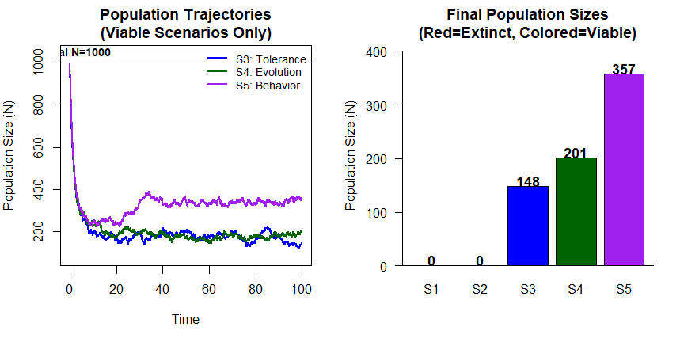

## 4.8 Verifying Phenotype-Environment Matching

The check_habitat_match() function visualizes phenotype–environment alignment by comparing survivor trait values with their occupied locations. It produces two panels: the landscape colored by environmental values (left) and survivor positions colored by phenotype or genotype values (right). Both panels share the same color scale. Effective matching is indicated when survivor dots visually “blend” with the underlying landscape gradient.

```r
par(mfrow = c(1, 1), mar = c(5, 4, 4, 2))

if (pop_s3 > 0) {
  check_habitat_match(sim_s3,
                           color_by = "phenotype",
                           landscape_colors = "terrain",
                           point_size = 1.5,
                           show_legend = TRUE)
}
```

```
#>
#> Habitat Matching Statistics (colored by Phenotype ):
#> ----------------------------
#> Number of survivors: 148
#> Phenotype distribution:
#>   Mean: 44.961
#>   Range: 6.306 to 83.283
#> Habitat value at survivor locations:
#>   Mean: 39.87
#>   Range: 0 to 100
#>
#> Phenotype-Habitat correlation:0.062
```

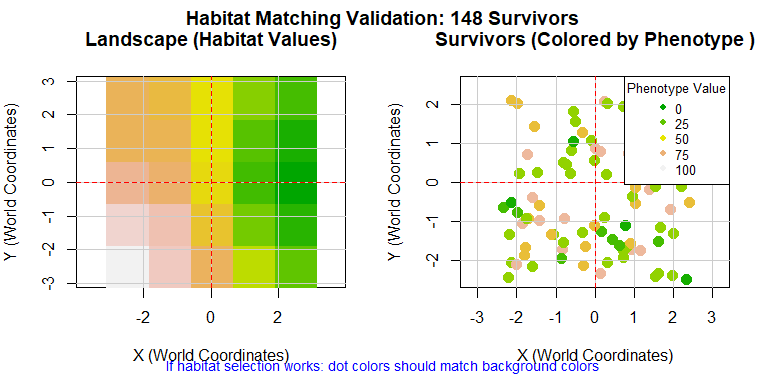

**Scenario 4 (Evolution added):** Mutation allows gradual shifts in genotype toward better local adaptation. Over the short simulation (100 events), changes are subtle, so the primary mechanism remains differential survival. Any improvement is seen as slightly tighter alignment between survivor traits and local environmental values.

```r
par(mfrow = c(1, 1))
if (pop_s4 > 0) {
  check_habitat_match(sim_s4,
                           color_by = "phenotype",
                           landscape_colors = "terrain",
                           point_size = 1.5,
                           show_legend = TRUE)
}
```

```
#>
#> Habitat Matching Statistics (colored by Phenotype ):
#> ----------------------------
#> Number of survivors: 201
#> Phenotype distribution:
#>   Mean: 31.085
#>   Range: 6.808 to 77.884
#> Habitat value at survivor locations:
#>   Mean: 43.538
#>   Range: 0 to 100
#>
#> Phenotype-Habitat correlation:0.109
```

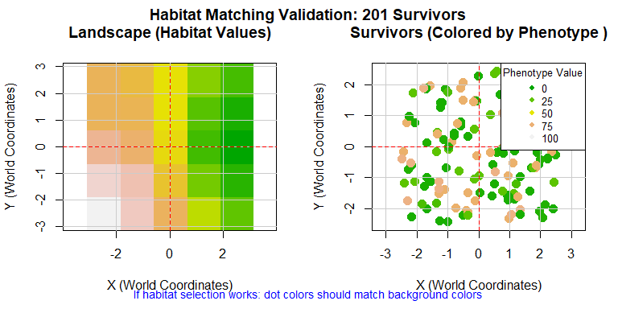

Plots resemble Scenario 3, with enhancements indicating subtle evolutionary adjustments.

**Scenario 5 (Habitat selection added):** Active habitat selection produces the strongest matching. Individuals evaluate multiple locations (`sampling_points=10`) and preferentially settle where their phenotype aligns with the local environment, guided by the softmax function with temperature=0.1.

```r
par(mfrow = c(1, 1))
if (pop_s5 > 0) {
  check_habitat_match(sim_s5,
                           color_by = "phenotype",
                           landscape_colors = "terrain",
                           point_size = 1.5,
                           show_legend = TRUE)
}
```

```
#>
#> Habitat Matching Statistics (colored by Phenotype ):
#> ----------------------------
#> Number of survivors: 357
#> Phenotype distribution:
#>   Mean: 56.822
#>   Range: 17.411 to 92.396
#> Habitat value at survivor locations:
#>   Mean: 39.885
#>   Range: 0 to 92.64
#>
#> Phenotype-Habitat correlation:0.602
#>   -> Positive match: individuals in habitat matching their phenotype
```

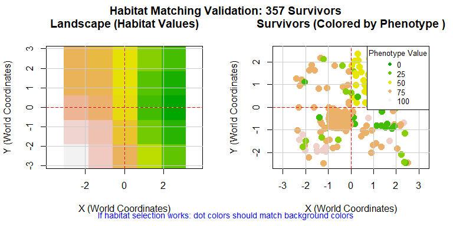

Plots show clear spatial segregation, with survivor dots closely aligned to the landscape gradient, demonstrating successful selection.

# 5 Computational Considerations

## 5.1 Performance Scaling

TWoLife’s computational cost is dominated by neighbor calculations that occur during each demographic event (birth, death, dispersal). Understanding these scaling relationships helps in designing feasible simulation experiments:

- **Population size**: Cost scales **quadratically** (O(N²)) with population size because each event requires updating neighbor lists (O(N) operation), and larger populations generate proportionally more events. Doubling population size increases runtime approximately 4-fold.
- **Landscape size**: Indirectly affects cost through carrying capacity. Larger landscapes support proportionally more individuals at equilibrium (density = N/area). Doubling landscape dimensions increases area 4-fold, supporting ~4× more individuals, which increases cost ~16-fold due to O(N²) scaling.
- **Habitat selection**: Cost scales linearly with `sampling_points`. Use sampling_points=1 for exploration, 10-100 when habitat selection mechanisms are scientifically important.
- **Simulation duration**: Cost scales linearly with `max_events`.

**Recommendation:** Start with smaller simulations (15-30 cell landscapes, N = 40-100, sampling_points = 1) for parameter exploration. Scale up cautiously, recognizing that doubling landscape dimensions costs ~16× more computation.

## 5.2 Memory Usage

Memory usage scales linearly with simulation duration because TWoLife stores complete event histories. Each event requires approximately 200-500 bytes depending on genetic architecture, so a simulation with 10,000 events requires roughly 2-5 MB. Memory is not a limiting factor for most applications, but for extremely long simulations (>1 million events), monitor memory usage.

# 6 References

Barrett, Rowan D. H., and Dolph Schluter. 2008. “Adaptation from Standing Genetic Variation.” *Trends in Ecology & Evolution* 23 (1): 38–44. https://doi.org/10.1016/j.tree.2007.09.008.

Bell, Graham, and Andrew Gonzalez. 2009. “Evolutionary Rescue Can Prevent Extinction Following Environmental Change.” *Ecology Letters* 12 (9): 942–48. https://doi.org/10.1111/j.1461-0248.2009.01350.x.

Bolnick, Daniel I., Priyanga Amarasekare, Márcio S. Araújo, Reinhard Bürger, Jonathan M. Levine, Mark Novak, Volker H. W. Rudolf, Sebastian J. Schreiber, Mark C. Urban, and David A. Vasseur. 2011. “Why Intraspecific Trait Variation Matters in Community Ecology.” *Trends in Ecology & Evolution* 26 (4): 183–92. https://doi.org/10.1016/j.tree.2011.01.009.

Bolnick, Daniel I., Richard Svanbäck, James A. Fordyce, Louie H. Yang, Jeremy M. Davis, C. Darrin Hulsey, and Matthew L. Forister. 2003. “The Ecology of Individuals: Incidence and Implications of Individual Specialization.” *The American Naturalist* 161 (1): 1–28. https://doi.org/10.1086/343878.

DeAngelis, Donald L., and Wolf M. Mooij. 2005. “Individual-Based Modeling of Ecological and Evolutionary Processes.” *Annual Review of Ecology, Evolution, and Systematics* 36: 147–68. https://doi.org/10.1146/annurev.ecolsys.36.102003.152644.

DeWitt, Thomas J., and Samuel M. Scheiner. 2004. “Phenotypic Variation from Single Genotypes.” In *Phenotypic Plasticity: Functional and Conceptual Approaches*, edited by Thomas J. DeWitt and Samuel M. Scheiner, 1–9. New York: Oxford University Press.

Fahrig, Lenore. 2003. “Effects of Habitat Fragmentation on Biodiversity.” *Annual Review of Ecology, Evolution, and Systematics* 34: 487–515. https://doi.org/10.1146/annurev.ecolsys.34.011802.132419.

Fretwell, Stephen D., and Henry L. Lucas. 1970. “On Territorial Behavior and Other Factors Influencing Habitat Distribution in Birds.” *Acta Biotheoretica* 19 (1): 16–36. https://doi.org/10.1007/BF01601953.

Futuyma, Douglas J., and Gabriel Moreno. 1988. “The Evolution of Ecological Specialization.” *Annual Review of Ecology and Systematics* 19: 207–33. https://doi.org/10.1146/annurev.es.19.110188.001231.

Gillespie, Daniel T. 1976. “A General Method for Numerically Simulating the Stochastic Time Evolution of Coupled Chemical Reactions.” *Journal of Computational Physics* 22 (4): 403–34. https://doi.org/10.1016/0021-9991(76)90041-3.

———. 1977. “Exact Stochastic Simulation of Coupled Chemical Reactions.” *The Journal of Physical Chemistry* 81 (25): 2340–61. https://doi.org/10.1021/j100540a008.

Grimm, Volker, and Steven F. Railsback. 2005. *Individual-Based Modeling and Ecology*. Princeton, NJ: Princeton University Press.

Hairston, Nelson G., Stephen P. Ellner, Monica A. Geber, Takehito Yoshida, and Jennifer A. Fox. 2005. “Rapid Evolution and the Convergence of Ecological and Evolutionary Time Scales.” *Proceedings of the Royal Society B* 272 (1573): 1405–12. https://doi.org/10.1098/rspb.2004.2977.

Justeau-Allaire, Dimitri, Ghislain Vieilledent, Nicolas Rinck, Philippe Vismara, Xavier Lorca, and Philippe Birnbaum. 2022. “Unifying Niche and Connectivity: NMR-Based Fragmented Landscape Generation with Spatial Structure Objectives.” *Methods in Ecology and Evolution* 13 (3): 717–26. https://doi.org/10.1111/2041-210X.13773.

Kawecki, Tadeusz J., and Dieter Ebert. 2004. “Conceptual Issues in Local Adaptation.” *Ecology Letters* 7 (12): 1225–41. https://doi.org/10.1111/j.1461-0248.2004.00684.x.

Lande, Russell. 1976. “Natural Selection and Random Genetic Drift in Phenotypic Evolution.” *Evolution* 30 (2): 314–34. https://doi.org/10.2307/2407703.

Levins, Richard. 1968. *Evolution in Changing Environments: Some Theoretical Explorations*. Princeton, NJ: Princeton University Press.

Lynch, Michael, and Bruce Walsh. 1998. *Genetics and Analysis of Quantitative Traits*. Sunderland, MA: Sinauer Associates.

McNamara, John M., and Alasdair I. Houston. 1987. “Stochastic Dynamic Programming and the Evolution of Behaviour.” *The American Naturalist* 130 (2): 220–36. https://doi.org/10.1086/284707.

Milne, Bruce T. 1992. “Spatial Aggregation and Neutral Models in Fractal Landscapes.” *The American Naturalist* 139 (1): 32–57. https://doi.org/10.1086/285312.

Pigliucci, Massimo. 2001. *Phenotypic Plasticity: Beyond Nature and Nurture*. Baltimore, MD: Johns Hopkins University Press.

Ravigné, Virginie, Ulf Dieckmann, and Isabelle Olivieri. 2009. “Live Where You Thrive: Joint Evolution of Habitat Choice and Local Adaptation Facilitates Specialization and Promotes Diversity.” *The American Naturalist* 174 (4): E141–69. https://doi.org/10.1086/605369.

Schoener, Thomas W. 2011. “The Newest Synthesis: Understanding the Interplay of Evolutionary and Ecological Dynamics.” *Science* 331 (6016): 426–29. https://doi.org/10.1126/science.1193954.

Violle, Cyrille, Brian J. Enquist, Brian J. McGill, Lin Jiang, Cécile H. Albert, Catherine Hulshof, Vincent Jung, and Julie Messier. 2012. “The Return of the Variance: Intraspecific Variability in Community Ecology.” *Trends in Ecology & Evolution* 27 (4): 244–52. https://doi.org/10.1016/j.tree.2011.11.014.

Wiens, John A. 1976. “Population Responses to Patchy Environments.” *Annual Review of Ecology and Systematics* 7: 81–120. https://doi.org/10.1146/annurev.es.07.110176.000501.